# Case Studies

Lecture 6 - LAS

Don van den Bergh

28-09-2026

## Today

$$\newcommand{\hypo}{\mathcal{H}}$$

Two statistical tests using two datasets:

- Z-test
- $t$-test

These are mostly the names for tests we’ve already applied during the previous lectures.

The workflow is mostly the same.

# The Statistical Workflow

## From a Question to a Conclusion

1. What is the *research question*?
2. What are the *population*, *sample*, *variables*, and *measurement levels*?
3. What do the *raw data* look like?
4. Which *descriptive statistics* are useful?
5. What are $\hypo_0$ and $\hypo_1$?
6. What would we expect because of *sampling variability* if $\hypo_0$ were true?
7. How far is our estimate from $\hypo_0$ in *standard errors*?
8. What is the *$p$-value*?
9. What does a *confidence interval* tell us?
10. What *can* and what *can’t* we conclude?

## The Recurring Test Statistic

For a sample mean,

$$SE_{\bar{x}} = \frac{s}{\sqrt{n}}.$$

The generic test statistic is

$$\text{test statistic}
=
\frac{\text{observed estimate} - \text{value under }\hypo_0}
{\text{standard error}}.$$

Interpretation:

*How many standard errors away from the null hypothesis is our estimate?*

# Case Study 1: Hit Songs

## How Long Is a Hit Song?

People often say:

> “Pop songs are about three minutes long.”

Is that a reasonable description of songs that reach number 1 on the Billboard Hot 100?

https://en.wikipedia.org/wiki/Three-minute_pop_song

## The Data

Let’s use a dataset on the Billboard Hot 100 Number Ones.

It contains 1177 songs that reached number 1 between 1958 and 2025, including their length in seconds.

We examine a sample of 30 songs.

Data: Chris Dalla Riva / TidyTuesday, Billboard Hot 100 Number Ones. Source: https://github.com/rfordatascience/tidytuesday/tree/main/data/2025/2025-08-26

## Population and Sample

What is the population we are trying to say something about?

- Billboard Hot 100 number-one songs, 1958–2025.

What is the measurement level?

- Ratio, because distances have a meaning and zero has a meaning.

For today’s analysis:

- *Population*: Billboard Hot 100 number-one songs in this database
- *Sample*: 30 randomly selected number-one songs
- *Variable*: song length in seconds
- *Measurement level*: ratio

## Our Sample

| Song | Artist | Year | Length (seconds) |
| --- | --- | --- | --- |
| Love Bites | Def Leppard | 1988 | 346 |
| Boom Boom Pow | The Black Eyed Peas | 2009 | 252 |
| Brandy (You're a Fine Girl) | Looking Glass | 1972 | 186 |
| Boogie Oogie Oogie | A Taste of Honey | 1978 | 338 |
| All Night Long (All Night) | Lionel Richie | 1983 | 260 |
| These Boots are Made for Walkin' | Nancy Sinatra | 1966 | 162 |
| I Swear | All-4-One | 1994 | 259 |
| Ringo | Lorne Greene | 1964 | 214 |
| Get Off Of My Cloud | The Rolling Stones | 1965 | 175 |
| Rain on Me | Lady Gaga &amp; Ariana Grande | 2020 | 182 |

[output cut: 2 more lines]

## First: Look at the Data

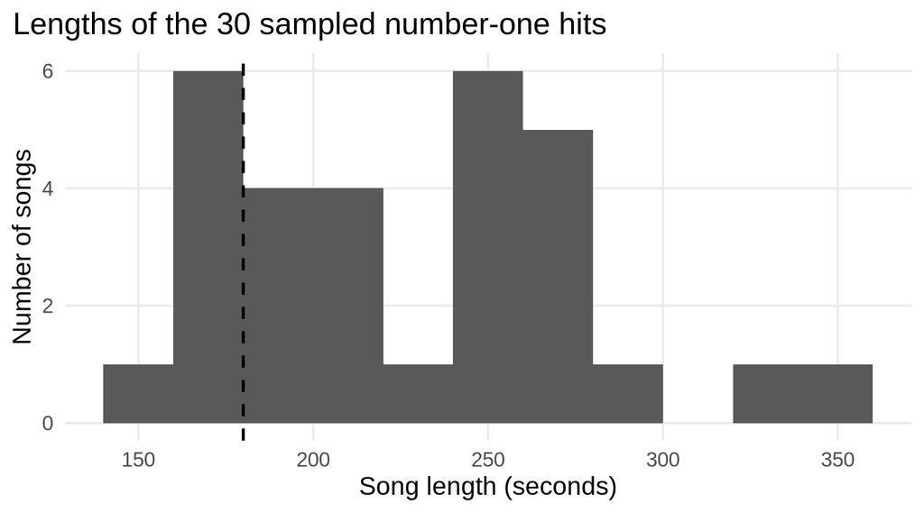

What do you notice?

## Describe the Sample

- $n = 30$
- Mean = 228.7 seconds
- Median = 222.5 seconds
- SD = 50.7 seconds

The median is near the mean, what does this tell us?

Distribution is roughly symmetric / little skew.

The sample mean is 48.7 seconds away from three minutes.

Is that a large difference?

## Hypotheses

Let $\mu$ be the population mean song length.

We test:

$$\hypo_0: \mu = 180 \qquad \text{against} \qquad \hypo_1: \mu \neq 180.$$

Is this one or two tailed?

Two-tailed. Why?

## Assume the Null Hypothesis is true

If $\hypo_0$ is true, the population mean is 180 seconds.

Even then, a random sample of 30 songs will almost never have a mean of *exactly* 180.

Why?

Sampling variability!

## Standard Error

Our estimate of the standard error is

$$SE_{\bar{x}}
=
\frac{s}{\sqrt{n}}.$$

For our data,

$$SE_{\bar{x}}
=
\frac{50.7}
{\sqrt{30}}
=
9.26 \text{ seconds}.$$

What does this number represent?

Note that we *estimate* SE rather than that we know it!

## Test Statistic

$$t =\frac{\bar{x} - 180}
{SE_{\bar{x}}}
=\frac{228.7 - 180}
{9.26}
= 5.26.$$

Our sample mean lies about 5.26 standard errors from the value predicted by $\hypo_0$.

The “degrees of freedom” are $df = 29$.

## The Sampling Distribution Under $\hypo_0$

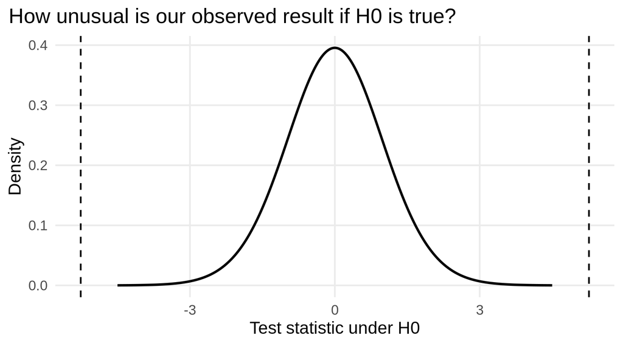

## The $p$-value

We know $df = n - 1 = 30 - 1 = 29$ and $t = 5.26$

Let’s examine the $t$-table to find the $p$-value.

Go to row $df = 29$ and go right until the next value exceeds $t=5.26$.

The *one-sided* probability in the table for a result at least this extreme under $\hypo_0$ is $p < 0.001$.

Since this is a two-sided test, we know

$$p < 2 \times 0.001 = 0.002.$$

Using $\alpha = .05$, we reject $\mathcal{H}_0$.

Why don’t we need to know the exact $p$-value?

## Confidence Interval

A 95% confidence interval for the population mean is

$$[
\bar{x} - t_{97.5\%,\,29} \times SE_{\bar{x}},\;
\bar{x} + t_{97.5\%,\,29} \times SE_{\bar{x}}
]$$

$$[209.8,\; 247.7]
\text{ seconds}.$$

Does 180 seconds fall inside this interval?

How does that relate to our hypothesis test?

- Because $\sigma$ is unknown, we replaced it with $s$. That means our standardized statistic follows a $t$-distribution rather than a standard normal distribution.
- Compared to last week, the only difference is using a $t$ distribution instead of a $Z$-distribution for the $p$-value and confidence interval.

## What if we examine all the data?

For teaching purposes, I pretended that these 30 songs were all data we had.

But this dataset contains 1177 songs obtained between 1958 and 2025.

So now we can look behind the curtain.

## The Population Distribution

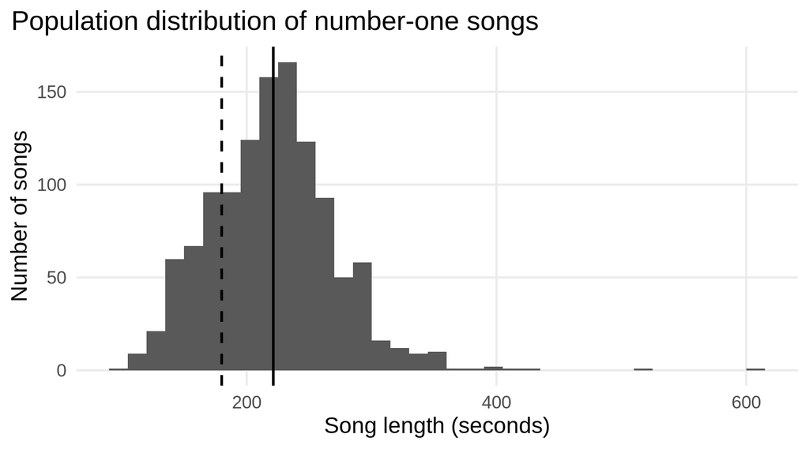

- Population mean: 221.3 seconds.
- Sample mean: 228.7 seconds.

## Case Study 1: Summary

- Population and sample
- Measurement levels
- Histograms
- Mean, median, and standard deviation
- Hypotheses
- Sampling variability
- Standard error
- Sampling distribution
- Test statistic
- $p$-value
- Confidence interval

## Case Study 1: Summary

We doubled the $p$-value because it was a two-sided test and the table gave a one-sided $p$-value.

We use a one-sample $t$-test because the standard devation was unknown/ estimated from the data.

What if we do know the standard deviation?

# Case Study 2: Movies

## Does Passing the Bechdel Test Pay?

Recall the Bechdel test.

A movie passes if:

1. it contains at least two named women,
2. who talk to each other,
3. about something other than a man.

Now we ask a different question:

> Among movies that pass, does the average movie earn back its production budget?

## Operationalize “Earn Back Its Budget”

To turn that question into a variable, let’s define *return on investment*:

$$ROI
=
\frac{\text{worldwide gross}}
{\text{production budget}}.$$

Then:

- $ROI = 1$: worldwide gross equals the production budget
- $ROI > 1$: worldwide gross exceeds the production budget
- $ROI < 1$: worldwide gross is below the production budget

Is this the same thing as *profit*?

## Operationalize “Earn Back Its Budget”

No.

Production budget is not the movie’s complete cost.

Worldwide box office is not the amount that goes directly to the studio.

So technically our variable is better described as:

“Worldwide box-office gross relative to production budget”

This is an *operationalization* of financial performance.

## Before Calculating Anything…

What do you expect the distribution of ROI to look like?

- Symmetric?
- Left-skewed?
- Right-skewed?
- Any outliers?

## Look at the Raw Data

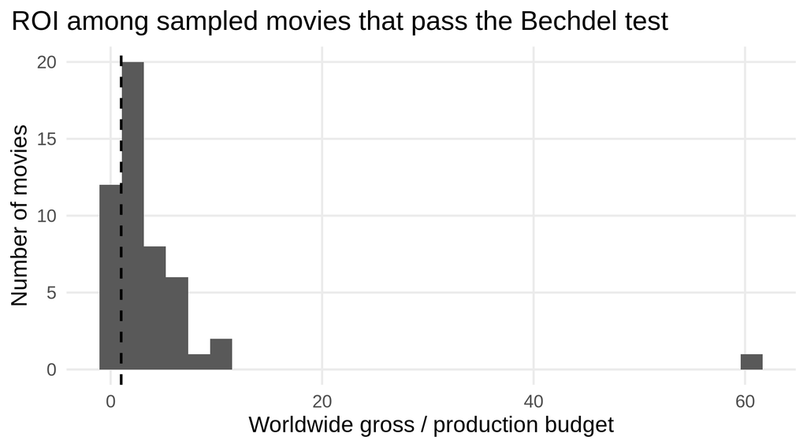

What do you notice?

## Mean or Median?

- Mean ROI = 4.17
- Median ROI = 2.66
- SD = 8.53

Why can the mean and median differ substantially here?

## But Our Hypothesis Is About a Mean

Let $\mu$ be the *population mean ROI* among passing movies in our sample.

We ask whether the average exceeds break-even:

$$\hypo_0: \mu \leq 1 \qquad \text{against} \qquad \hypo_1: \mu > 1.$$

This is a *one-tailed Z-test*.

To conduct the test, we evaluate the null at the boundary:
$$\mu_0 = 1.$$

## What Comes Next?

We know:

- $\bar{x} = 4.17$
- $n = 50$

Suppose, that some previous large-scale research established that the standard deviation of this gross-to-budget ratio is $\sigma = 16.54$.

What should we calculate next?

$$SE_{\bar{x}} = \frac{\sigma}{\sqrt{n}}.$$

## Standard Error

$$SE_{\bar{x}}
=
\frac{16.54}
{\sqrt{50}}
=
2.339.$$

A highly variable distribution of raw varlues can still give a much less variable distribution of sample means.

## Test Statistic

Under $\hypo_0$, the expected population mean is 1.

What is the test statistic?

$$Z
=\frac{\bar{x} - 1}
{SE_{\bar{x}}}
=
\frac{4.17 - 1}
{2.339}
=
1.36.$$

## Interpret It Before Looking at $p$

Our observed mean is 1.36 standard errors above the value predicted by $\hypo_0$.

If you had to guess the $p$-value, is it:

- large,
- around .05,
- or very small?

## Sampling Distribution and $p$-value

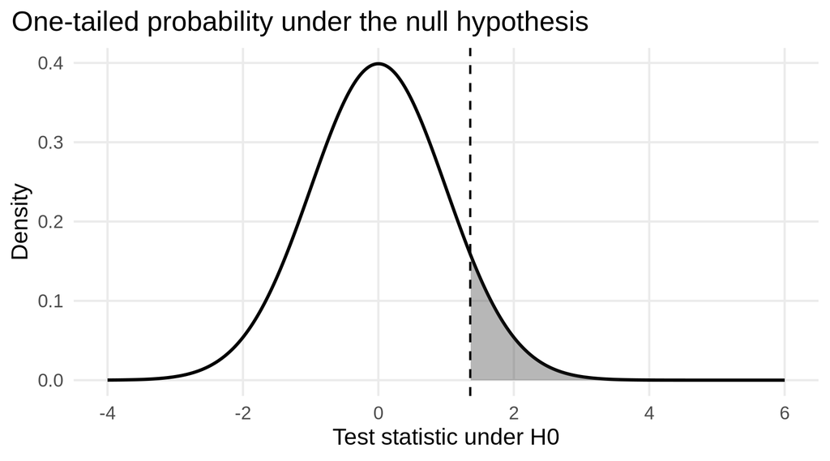

## Conclusion

$$p = 0.087.$$

Using $\alpha=.05$:

**We do not reject $\mathcal{H}_0$.**

## Confidence Interval

The ordinary two-sided 95% confidence interval is

$$[-0.41,\; 8.76].$$

What does this add beyond the $p$-value?

It contains 0!

It contains 1! The value expected under $\hypo_0$ is 1!

## Does Skewness Break Everything?

The raw ROI values are strongly skewed.

But our test concerns the sample mean.

So the relevant question is:

> What does the sampling distribution of the sample mean look like?

## Raw Distribution

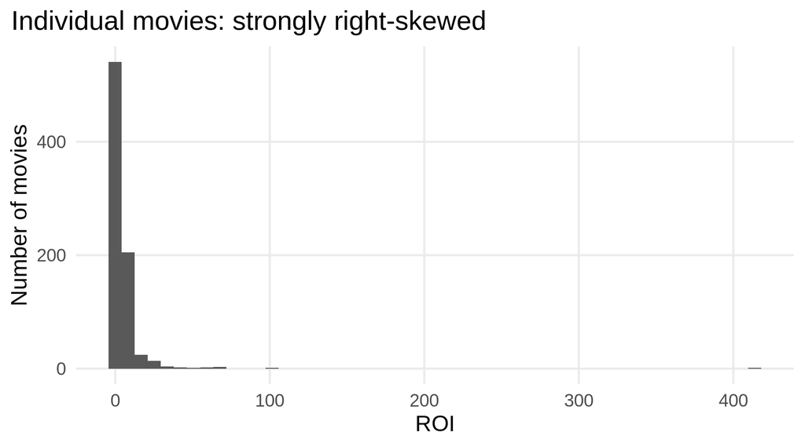

## Sampling Distribution

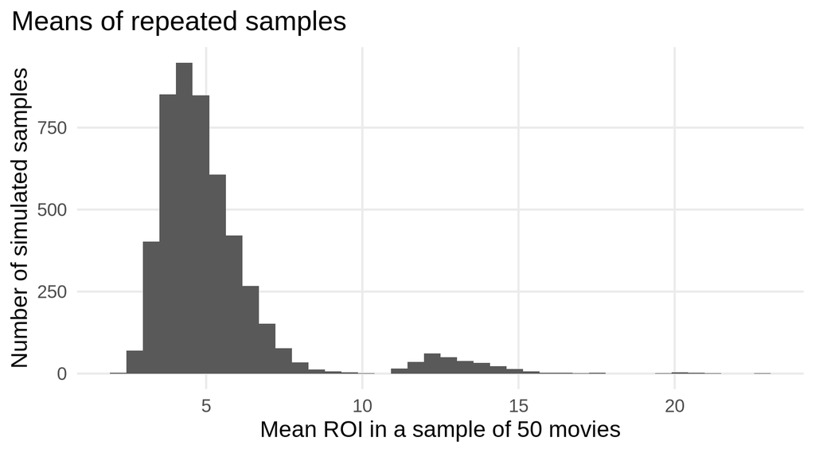

The Central Limit Theorem is about the *second* distribution.

## Sampling Distribution

In this case, the sampling distribution doesn’t look normal.

Keep in mind, that the CLT talks about *the limit*.

A rule of thumb says $n = 30$ is often enough for the CLT to give a useful approximation.

- But, as we saw, this isn’t always enough.

## What if we had larger samples?

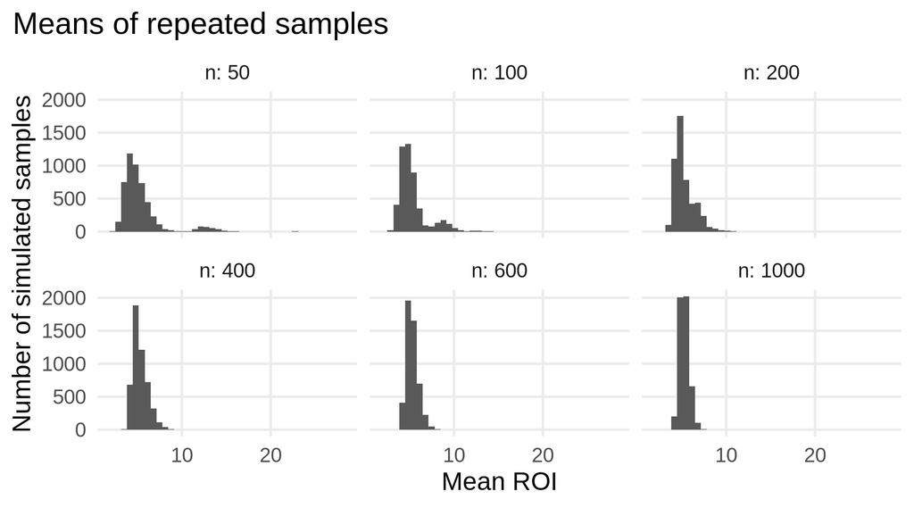

## A More Important Problem

Suppose our calculations are all correct.

What exactly can we generalize to?

The dataset is *not* a simple random sample of every movie ever made.

## Statistical Significance Is Not Enough

A small $p$-value answers a narrow question:

- Are these data evidence against $\hypo_0$?

It does *not* automatically tell us:

- whether the effect is important,
- whether the measurement is ideal,
- whether the sample represents the target population

## Case Study 2: What Changed?

The statistical machinery was nearly identical.

- We used a $Z$-test instead of a $t$-test.

But the data raised new questions about:

- skewness and outliers,
- mean versus median,
- operationalization,
- the target population,
- external validity.

Good statistics is more than calculating the correct formula.

## The Core Pattern

In both cases:

$$\text{observed sample}
\longrightarrow
\text{estimate}
\longrightarrow
\text{standard error}$$

$$\longrightarrow
\text{sampling distribution under }\hypo_0
\longrightarrow
p
\longrightarrow
\text{conclusion}.$$

The **story** changes.

The statistical logic does not.

## What Does a Test Statistic Mean?

Suppose

$$t = -2.4.$$

What does that mean?

> The observed estimate lies **2.4 standard errors below** the value predicted by the null hypothesis.

This interpretation is much more useful than memorizing formulas.

## What Does a Confidence Interval Mean?

A 95% confidence interval is **not**:

> “There is a 95% probability that $\mu$ lies in this particular interval.”

Instead:

> If we repeated the procedure many times, 95% of the intervals produced by this procedure would contain the true population value.

(The first interpretation is the Bayesian credible interval)

## Raw Distribution vs. Sampling Distribution

This distinction appeared repeatedly today.

*Raw-data distribution*

- describes individual observations
- e.g., individual movies or songs

*Sampling distribution*

- describes a statistic over repeated samples
- e.g., sample means
- determines the uncertainty of our estimate

## What Happens When $n$ Increases?

If the population variability stays the same:

$$SE_{\bar{x}} = \frac{s}{\sqrt{n}}.$$

As $n$ increases:

- the standard error decreases,
- the sampling distribution becomes narrower,
- estimates become more precise,
- power generally increases.

## But Large $n$ Does Not Fix Everything

A huge sample does *not* automatically fix:

- poor measurement,
- selection bias,
- an irrelevant target population,
- confounding,
- bad research questions.

Statistics quantifies *sampling uncertainty*.

## Comparison

|  | Billboard | Bechdel |
| --- | --- | --- |
| Question about | Mean | Mean |
| $\sigma$ | Unknown | Known |
| Standard error | $s/\sqrt{n}$ | $\sigma/\sqrt{n}$ |
| Test statistic | $t$ | $Z$ |
| Reference distribution | $t_{n-1}$ | $N(0,1)$ |
| $df$ | $n-1$ | — |